# Group_01_Project2_demo

Group_01

# Introduction

Data come from the FIES (Family Income and Expenditure Survey) recorded in the Philippines. The survey, which is undertaken every three years, is aimed at providing data on family income and expenditure. The data obtained from this survey are from different regions across the Philippines. This report will focus on one individual area, the Cordillera Administrative Region and so region has been removed from the dataset as it will not be informative as an explanatory variable.

The report will investigate which household related variables influence the number of people living in a household. The data used consists of 1725 observations of ten variables, two of which are categorical and the remaining are numerical.

# Exploratory Data Analysis

Figure 1 shows the distribution of the response variable: Number of members in a household (variable name “Total.number.of.family.members”). The modal response is 4 members and the distribution is right-skewed,

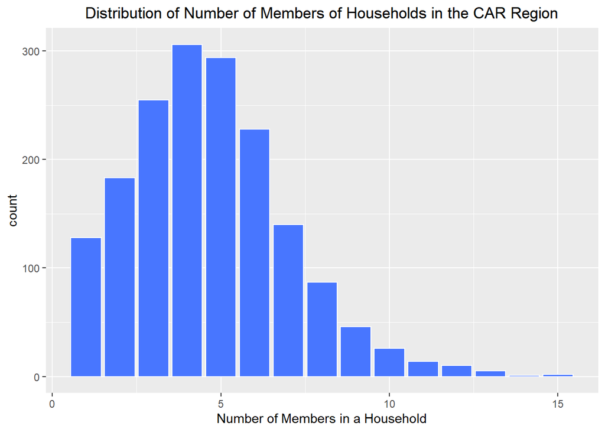

Distribution of Response Variable

Figure 2 shows a graphical visualisation for all the variables in the data set.

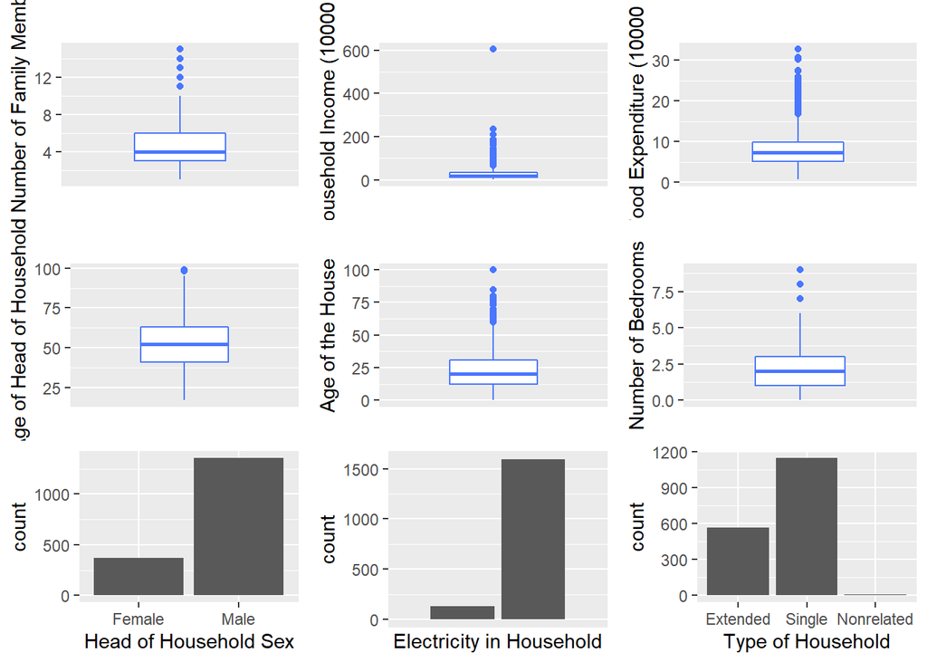

Graphical Summaries of Variables

Table 1 shows summary data for all the numerical variables.There is no missing data within these variables and so no values will need to be imputed for the analysis in the report. The response variable, total number of family members in a household, ranges from 1 to 15, with the middle 50% of number of family members falling between 3 and 6 also an average number of family members of 4.67. There appear to be possible outliers at the maximum values of Total Household Income and House Floor Area. The total household income is range from 11988 to 6042860 Philippine Peso. The middle 50% of total household income is between 118565 and 328335, with an income of 269540.48 peso on average. The third variable is total food expenditure, in Phillipine peso, which is the range of 6781 to 327724, with the middle 50% lies between 51922 and 98493. Then, the household head’s age is range from 17 to 99 years, with the middle 50% falling between 41 and 63 years of age. Next, the house floor area is range from 5 to 900 square metres. The central 50% of the variable house floor area is between 32 and 102 with an average area of 90.92. The sixth explanatory variable is the house (building) age and it ranges in value from 0 to 100, with the middle 50% falling between 12 and 31. The number of bedrooms in the house ranges from 0 to 9 with a mean average number of bedrooms of 2.26 per household. Finally, we may look at the binary variable electricity, which denotes whether the property has electricity access or not, the average score of electricity is 0.93, which means 93% household have electricity.

Summary statistics of numerical variables

| Variable | Missing | Complete | Mean | SD | Min. | 1st Q. | Median | 3rd Q. | Max. |
| --- | --- | --- | --- | --- | --- | --- | --- | --- | --- |
| Total.Number.of.Family.members | 0 | 1 | 4.67 | 2.33 | 1.00 | 3.00 | 4.00 | 6.00 | 15.00 |
| Total.Household.Income | 0 | 1 | 26.95 | 27.46 | 1.20 | 11.86 | 18.86 | 32.83 | 604.29 |
| Total.Food.Expenditure | 0 | 1 | 8.04 | 4.12 | 0.68 | 5.19 | 7.36 | 9.85 | 32.77 |
| Household.Head.Age | 0 | 1 | 52.23 | 14.52 | 17.00 | 41.00 | 52.00 | 63.00 | 99.00 |
| House.Floor.Area | 0 | 1 | 90.92 | 99.20 | 5.00 | 32.00 | 54.00 | 102.00 | 900.00 |
| House.Age | 0 | 1 | 22.98 | 15.32 | 0.00 | 12.00 | 20.00 | 31.00 | 100.00 |
| Number.of.bedrooms | 0 | 1 | 2.26 | 1.44 | 0.00 | 1.00 | 2.00 | 3.00 | 9.00 |
| Electricity | 0 | 1 | 0.93 | 0.26 | 0.00 | 1.00 | 1.00 | 1.00 | 1.00 |

The correlation coefficient between all numerical variables are shown in Table 2. There is a moderate positive correlation (0.611) between the total household income and the household food expenditure. Additionally there is a slight positive correlation between the total household income and the number of bedrooms in the household (0.441) and the number of family members and total food expenditure (0.469). The other variables are all weakly correlated.The correlation coefficient between household Head’s age, house floor area, house age and total number of family members are negative, which shows the rise of those three variables will lead to a reduction in the expected number of family members in a household.

Correlation of all variables.

|  | Total.Number.of.Family.members | Total.Household.Income | Total.Food.Expenditure | Household.Head.Age | House.Floor.Area | House.Age | Number.of.bedrooms | Electricity |
| --- | --- | --- | --- | --- | --- | --- | --- | --- |
| Total.Number.of.Family.members | 1.000 | 0.192 | 0.469 | -0.065 | -0.014 | -0.070 | 0.072 | 0.092 |
| Total.Household.Income | 0.192 | 1.000 | 0.611 | 0.063 | 0.234 | 0.025 | 0.441 | 0.149 |
| Total.Food.Expenditure | 0.469 | 0.611 | 1.000 | -0.052 | 0.124 | 0.007 | 0.356 | 0.199 |
| Household.Head.Age | -0.065 | 0.063 | -0.052 | 1.000 | 0.091 | 0.218 | 0.154 | -0.013 |
| House.Floor.Area | -0.014 | 0.234 | 0.124 | 0.091 | 1.000 | 0.074 | 0.374 | 0.107 |
| House.Age | -0.070 | 0.025 | 0.007 | 0.218 | 0.074 | 1.000 | 0.123 | 0.085 |
| Number.of.bedrooms | 0.072 | 0.441 | 0.356 | 0.154 | 0.374 | 0.123 | 1.000 | 0.214 |
| Electricity | 0.092 | 0.149 | 0.199 | -0.013 | 0.107 | 0.085 | 0.214 | 1.000 |

Table 3 shows the summaries of the two categorical variables. Single family households make up approximately two-thirds of the survey responses in this region and only 0.5% (8) of responses came from households formed of non-related individuals. Of the 1725 households, less than a quarter (21.4%) had a female head of household.

Summary of Categorial Explanatory Variables

| Household.Head.Sex | n | percent |
| --- | --- | --- |
| Female | 369 | 21.4% |
| Male | 1356 | 78.6% |
| Total | 1725 | 100.0% |

| Type.of.Household | n | percent |
| --- | --- | --- |
| Extended Family | 569 | 33.0% |
| Single Family | 1148 | 66.6% |
| Two or More Nonrelated Persons/Members | 8 | 0.5% |
| Total | 1725 | 100.0% |

The pairs plot in Figure 3 is colour coded to illustrate any differences between the distributions of the quantitative variables when the head of household sex is included as a factor. The plots suggest the sex of the head of household may impact the number of family members in the household and the age of the head of the household.

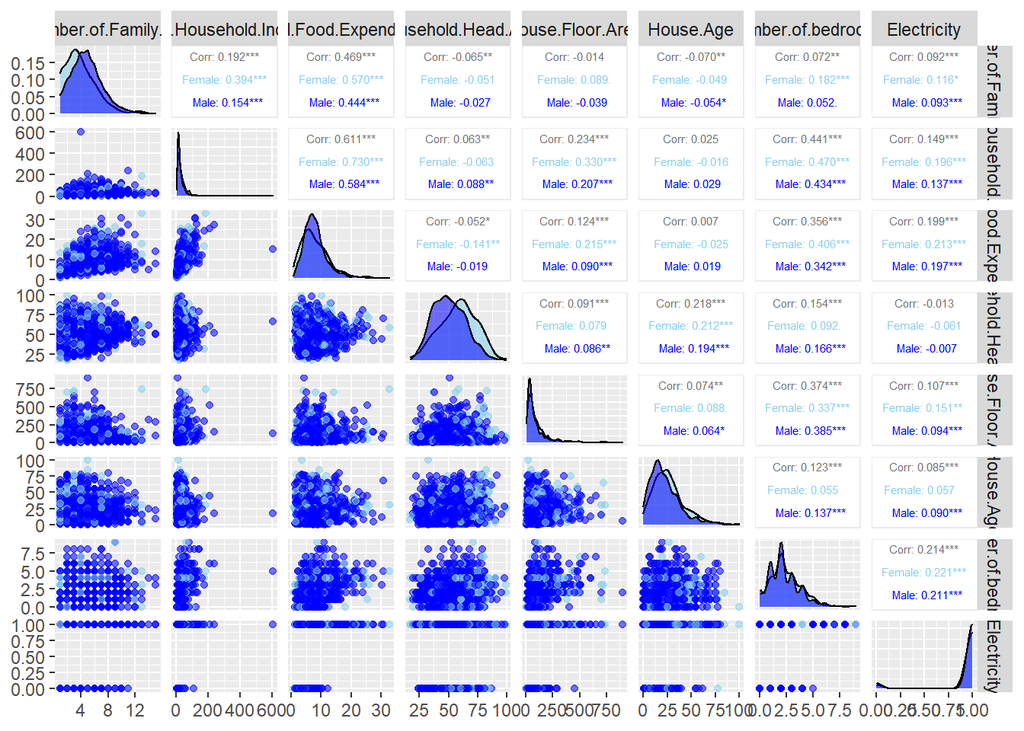

Pair plots and correlation between numerical variables, colour coded to show the sex of the head of household.

Figure 4 shows that an extended family household or one formed by non-related individuals is more likely to have a female head, whereas a larger proportion of single family households have male heads.

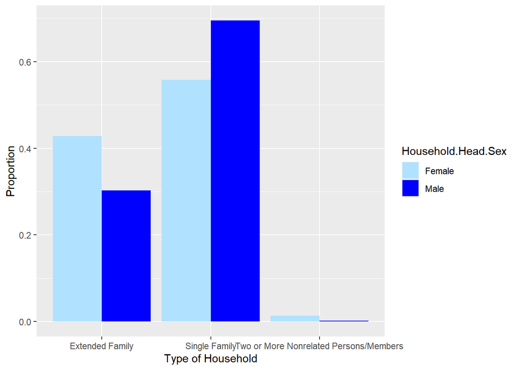

Barplot of household head’s sex by type of household

# Analysis of Relationships between Covariates

## The relationship between independent and dependent variables

We will explore whether nine variables related to households in the dataset have an impact on the number of people living in the house (Total.Number.of.Family.members). These nine variables are Annual household income, Annual expenditure by the household on food, Head of the household’s sex, Head of the household’s age, Type of Household, Floor area of the house, Age of the building, Number of bedrooms in the house and the presence or absence of an electricity supply to the house.

Figure 5 displays scatterplots and boxplots of the response variable versus the explanatory variables.

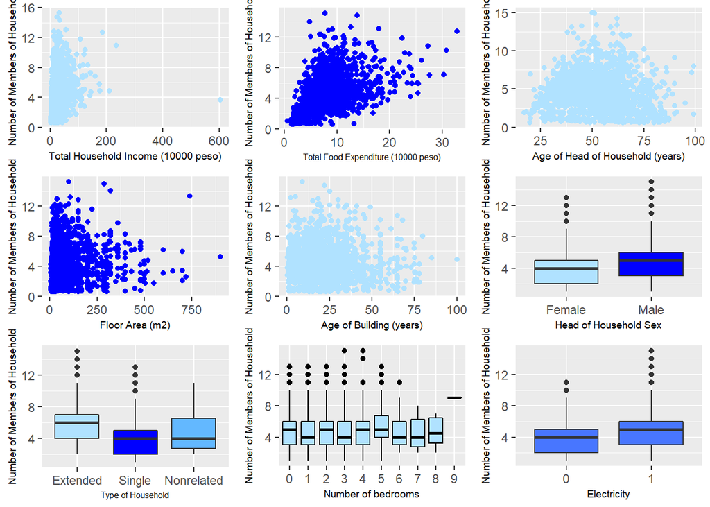

Scatterplots and Boxplots of each predictor against the response variable

From Figure 5, it can be seen that total food expenditure (in 10000 peso), age of the head of household, sex of the head of household and age of the house seem to have a weak effect on the number of people in the household. However, we will analyze the details below by GLM.

## Gender & Age

As highlighted by the pairs plot in Figure 3, there appears to be a relationship between the sex and age of the head of the household.

The minimum and maximum ages of household heads do not appear to differ greatly according to the individuals’ sex, however they do differ at the 25th, 50th and 75th percentiles with male heads of households being consitently younger than their female counterparts. The standard deviation is also greater for the female group, but the substantially smaller group size for females may contribute to this larger variation.

Summary statistics on the age of household heads by sex.

| Household.Head.Sex | n | Mean | St.Dev | Min | Q1 | Median | Q3 | Max |
| --- | --- | --- | --- | --- | --- | --- | --- | --- |
| Female | 369 | 58.23 | 15.69 | 17 | 47 | 59 | 69 | 99 |
| Male | 1356 | 50.59 | 13.74 | 20 | 40 | 49 | 61 | 98 |

The boxplot in Figure 6 illustrates the previously summarised data. The boxplot identifies the two oldest male head of households as outliers (shown by the points above the whisker), however within the context of the data and when compared to the ages of female head of household boxplot, these ages do not appear unreasonable or unrealistic.

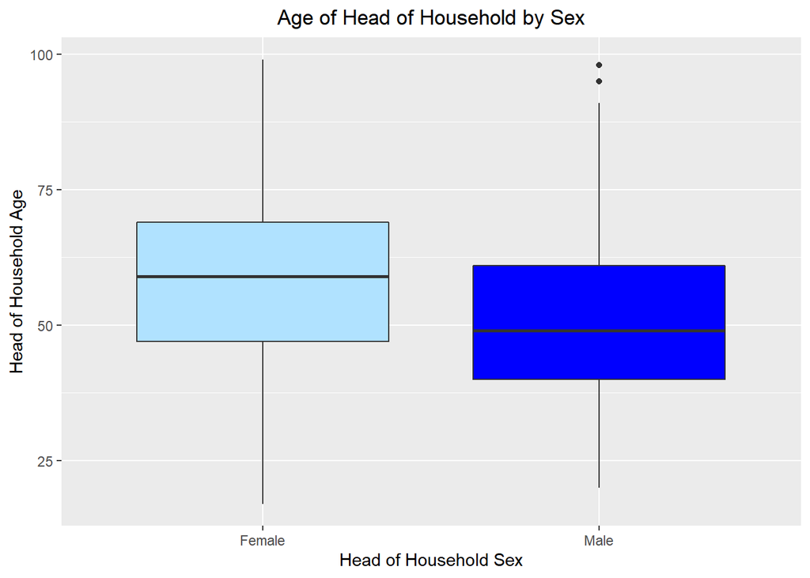

Boxplots of Head of Household Age stratified by Sex

The following Mann-Whitney U-test shows that there is a statistically significant difference in the median ages of male and female head of households at a 5% level.

```
    Wilcoxon rank sum test with continuity correction

data:  data.gender$Household.Head.Age by data.gender$Household.Head.Sex
W = 324284, p-value < 2.2e-16
alternative hypothesis: true location shift is not equal to 0
```

## Household Income and Food Expenditure

Figure 7 shows a boxplot of household incomes suggests a heavily skewed distribution with many outliers at the upper end of the distribution.

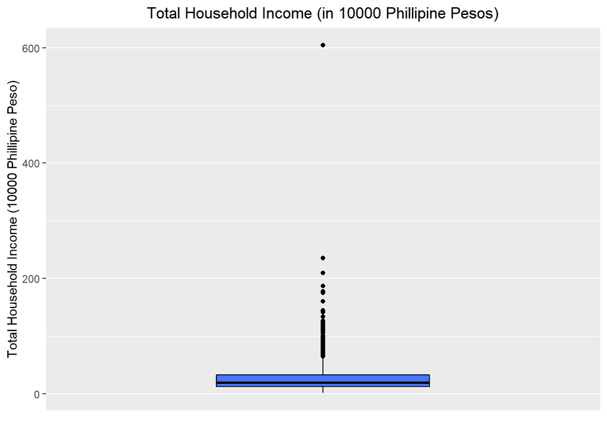

Household Incomes in 10000 Phillipine Pesos.

The boxplot in Figure 8 shows the log transformed household income and shows there are still several outliers following the transformation.

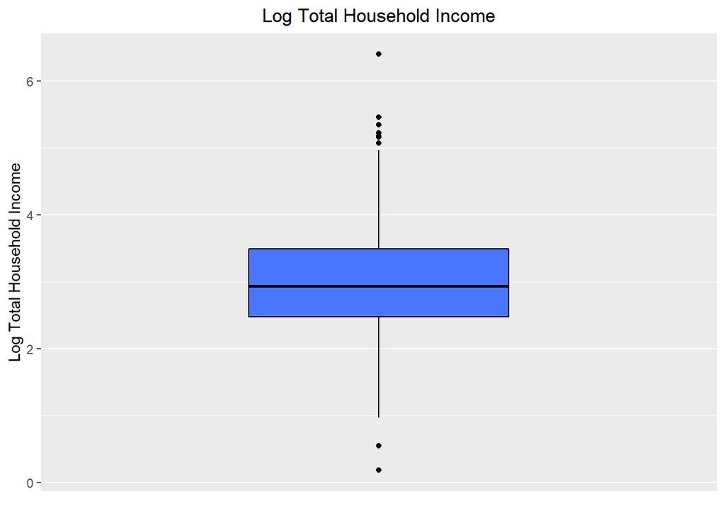

Boxplot of log transformed Incomes.

The scatterplot in Figure 9 of total household income against total food expenditure suggests a moderate positive correlation but the fitted model may be being heavily influenced by the extreme values, particularly by one extreme point.

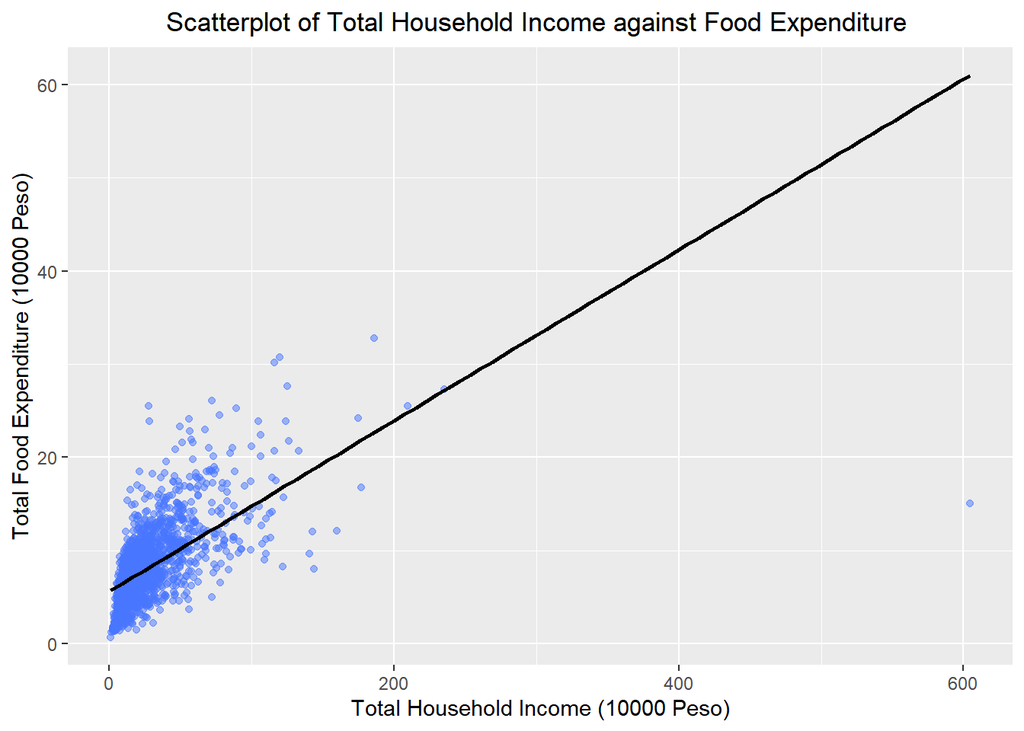

Scatterplot of Income against Food Expenditure.

Figure 9 again highlights a possible outlier in terms of income, this could be a data entry error or just an outlier at the maximum. Removing this observation from the data set and plotting provides the following scatter diagram in Figure 10. This plot reconfirms the suggested positive correlation, but there is still an imbalance in the amount of data available at different levels of income. For example, most data is available for incomes between 0 and 750000 peso, but far fewer data points occur above this income level.

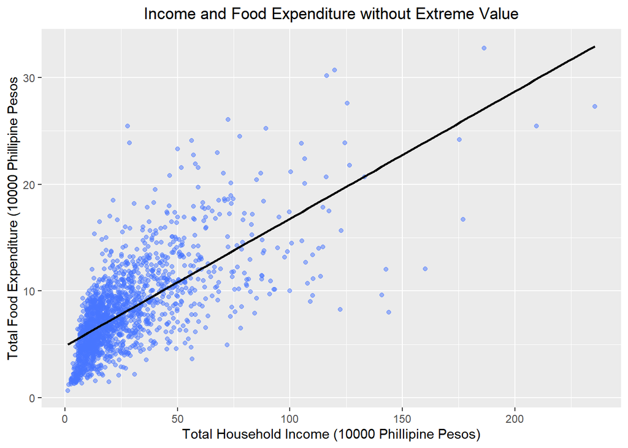

Scatterplot of Income and Food Expenditure with extreme value removed.

## Number of Family Members & Head of Household Sex

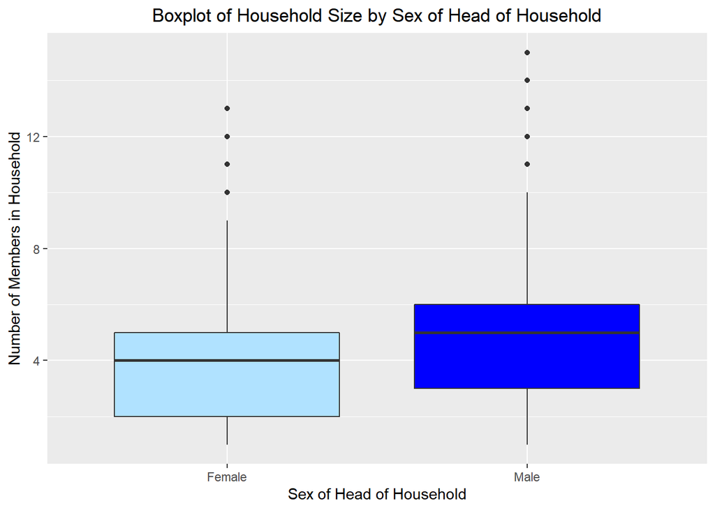

Number of Members in Household by Sex of Head of Household

Hence we can see from Figure 11 that households with a male head appear to have a greater number of family members on average than those with a female head, as the male group has larger values for the first and third quartiles and the median. However there is overlap between the two groups central IQR and so the distributions may not be significantly different.

Figure 12 shows that an extended family household or one formed by non-related individuals is more likely to have a female head, whereas a larger proportion of single family households have male heads.

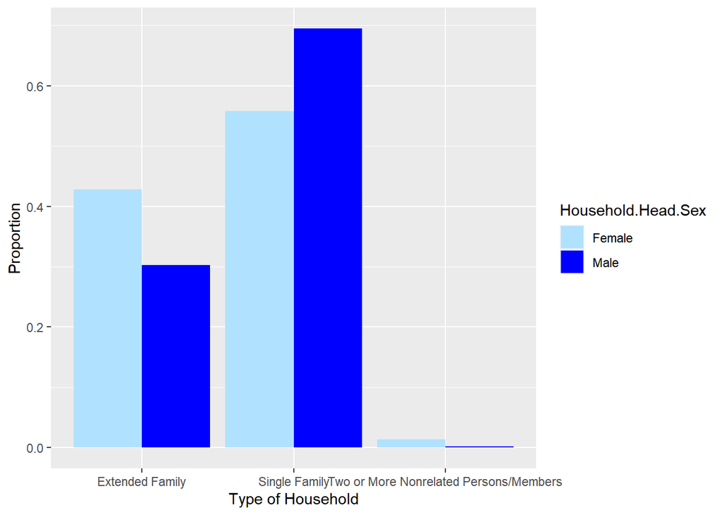

Barplot of household head’s sex by type of household

# Exploratory Model Analysis

## GLM Model Exploration

Prior to exploring any models, the outlier for Total Household Income and corresponding measurements for the other variables from this individual are removed.

The following code identifies which explanatory variables would be included to produce the best models of different sizes, in this instance the maximum number of variables specified is ten. The output suggests the first predictor to be included is the total food expenditure in 10000 Philippine pesos, and the last to be included is the binary variable Electricity that identifies if a household has electricity. Comparing each of the ten models produced by BIC, CP and adjusted R^2 selection criteria is inconclusive as each implies a different model is best.

```
Subset selection object
Call: regsubsets.formula(Total.Number.of.Family.members ~ ., data = data,
    nvmax = 10)
10 Variables  (and intercept)
                                                        Forced in Forced out
Total.Household.Income                                      FALSE      FALSE
Total.Food.Expenditure                                      FALSE      FALSE
Household.Head.SexMale                                      FALSE      FALSE
Household.Head.Age                                          FALSE      FALSE
Type.of.HouseholdSingle Family                              FALSE      FALSE
Type.of.HouseholdTwo or More Nonrelated Persons/Members     FALSE      FALSE
House.Floor.Area                                            FALSE      FALSE
House.Age                                                   FALSE      FALSE
Number.of.bedrooms                                          FALSE      FALSE
Electricity                                                 FALSE      FALSE
1 subsets of each size up to 10
Selection Algorithm: exhaustive
          Total.Household.Income Total.Food.Expenditure Household.Head.SexMale
1  ( 1 )  " "                    "*"                    " "
2  ( 1 )  " "                    "*"                    " "
3  ( 1 )  " "                    "*"                    "*"
4  ( 1 )  "*"                    "*"                    "*"
5  ( 1 )  "*"                    "*"                    "*"
6  ( 1 )  "*"                    "*"                    "*"
7  ( 1 )  "*"                    "*"                    "*"
8  ( 1 )  "*"                    "*"                    "*"
9  ( 1 )  "*"                    "*"                    "*"
10  ( 1 ) "*"                    "*"                    "*"
          Household.Head.Age Type.of.HouseholdSingle Family
1  ( 1 )  " "                " "
2  ( 1 )  " "                "*"
3  ( 1 )  " "                "*"
4  ( 1 )  " "                "*"
5  ( 1 )  " "                "*"
6  ( 1 )  " "                "*"
7  ( 1 )  "*"                "*"
8  ( 1 )  "*"                "*"
9  ( 1 )  "*"                "*"
10  ( 1 ) "*"                "*"
          Type.of.HouseholdTwo or More Nonrelated Persons/Members
1  ( 1 )  " "
2  ( 1 )  " "
3  ( 1 )  " "
4  ( 1 )  " "
5  ( 1 )  " "
6  ( 1 )  " "
7  ( 1 )  " "
8  ( 1 )  " "
9  ( 1 )  "*"
10  ( 1 ) "*"
          House.Floor.Area House.Age Number.of.bedrooms Electricity
1  ( 1 )  " "              " "       " "                " "
2  ( 1 )  " "              " "       " "                " "
3  ( 1 )  " "              " "       " "                " "
4  ( 1 )  " "              " "       " "                " "
5  ( 1 )  " "              "*"       " "                " "
6  ( 1 )  " "              "*"       "*"                " "
7  ( 1 )  " "              "*"       "*"                " "
8  ( 1 )  "*"              "*"       "*"                " "
9  ( 1 )  "*"              "*"       "*"                " "
10  ( 1 ) "*"              "*"       "*"                "*"
```

```
Adj.R2     CP    BIC
     9      8      6
```

# Formal Model Analysis

## Poisson Regression model

The response variable of the Total Number of Family Members (or members of the household) can be viewed as a count and therefore a Poisson Regression model is considered. For a Poisson model to be suitable, the mean and variance should be equal and so these assumptions are checked first.

Mean and Variation of Response Variable

| Mean | 4.669373 |
| --- | --- |
| Variance | 5.446049 |

From Table 5, we see the variation of total number of family members is only marginally larger than the mean of total number of family members, thus, the possibility of over-dispersion in our model is not a significant issue.

| Observations | 1724 |
| --- | --- |
| Dependent variable | Total.Number.of.Family.members |
| Type | Generalized linear model |
| Family | poisson |
| Link | log |

| χ2(10) | 693.90 |
| --- | --- |
| Pseudo-R2 (Cragg-Uhler) | 0.34 |
| Pseudo-R2 (McFadden) | 0.09 |
| AIC | 7011.64 |
| BIC | 7071.61 |

|  | Est. | S.E. | z val. | p |
| --- | --- | --- | --- | --- |
| (Intercept) | 1.43 | 0.08 | 17.90 | 0.00 |
| Total.Household.Income | -0.00 | 0.00 | -3.33 | 0.00 |
| Total.Food.Expenditure | 0.05 | 0.00 | 14.08 | 0.00 |
| Household.Head.Age | -0.00 | 0.00 | -2.89 | 0.00 |
| House.Floor.Area | -0.00 | 0.00 | -1.51 | 0.13 |
| House.Age | -0.00 | 0.00 | -3.00 | 0.00 |
| Number.of.bedrooms | -0.01 | 0.01 | -1.53 | 0.13 |
| Electricity | 0.03 | 0.05 | 0.58 | 0.56 |
| Household.Head.SexMale | 0.22 | 0.03 | 7.41 | 0.00 |
| Type.of.HouseholdSingle Family | -0.35 | 0.02 | -14.04 | 0.00 |
| Type.of.HouseholdTwo or More Nonrelated Persons/Members | -0.14 | 0.16 | -0.90 | 0.37 |

Standard errors: MLE

The poisson model fitted with all possible covariates concludes there are six statistically significant predictors at the 5% level. These are the total household income and food expenditure, the age and gender of the head of the household, the age of the house and if it is a single family household. Table 6 shows the estimates and the lower and upper bounds of the 95% confidence intervals for the regression parameters. The rows containing significant predictors, and so where the confidence intervals do not include 0, are highlighted. We can clearly see that the confidence intervals for area, number of bedrooms, and electricity access include 0. This indicates that these three variables have essentially no effect on the number of people in the household, which exactly validates the results for the p-value as well.

Estimates and the corresponding 95% Confidence Intervals, with significant predictors highlighted.

|  | Lower Bound | Estimate | Upper Bound |
| --- | --- | --- | --- |
| (Intercept) | 1.2687606 | 1.4254422 | 1.5810043 |
| Total.Household.Income | -0.0035110 | -0.0022045 | -0.0009192 |
| Total.Food.Expenditure | 0.0430507 | 0.0500316 | 0.0569775 |
| Household.Head.Age | -0.0042279 | -0.0025205 | -0.0008148 |
| House.Floor.Area | -0.0004469 | -0.0001932 | 0.0000552 |
| House.Age | -0.0038392 | -0.0023168 | -0.0008069 |
| Number.of.bedrooms | -0.0333633 | -0.0145830 | 0.0041111 |
| Electricity | -0.0644803 | 0.0276347 | 0.1219537 |
| Household.Head.SexMale | 0.1623556 | 0.2202770 | 0.2788479 |
| Type.of.HouseholdSingle Family | -0.3967514 | -0.3481835 | -0.2995260 |
| Type.of.HouseholdTwo or More Nonrelated Persons/Members | -0.4743426 | -0.1444455 | 0.1540719 |

| Observations | 1724 |
| --- | --- |
| Dependent variable | Total.Number.of.Family.members |
| Type | Generalized linear model |
| Family | poisson |
| Link | log |

| χ2(7) | 687.54 |
| --- | --- |
| Pseudo-R2 (Cragg-Uhler) | 0.33 |
| Pseudo-R2 (McFadden) | 0.09 |
| AIC | 7012.00 |
| BIC | 7055.62 |

|  | Est. | S.E. | z val. | p |
| --- | --- | --- | --- | --- |
| (Intercept) | 1.43 | 0.07 | 21.27 | 0.00 |
| Total.Household.Income | -0.00 | 0.00 | -4.59 | 0.00 |
| Total.Food.Expenditure | 0.05 | 0.00 | 14.29 | 0.00 |
| Household.Head.Age | -0.00 | 0.00 | -3.21 | 0.00 |
| House.Age | -0.00 | 0.00 | -3.23 | 0.00 |
| Household.Head.SexMale | 0.22 | 0.03 | 7.42 | 0.00 |
| Type.of.HouseholdSingle Family | -0.35 | 0.02 | -14.08 | 0.00 |
| Type.of.HouseholdTwo or More Nonrelated Persons/Members | -0.14 | 0.16 | -0.85 | 0.39 |

Standard errors: MLE

It is important to note that the p-value for Family type of two or more unrelated individuals is greater than 0.05, thus indicating that a family type of two or more nonrelated persons is not a statistically significant explanatory variable, but households composed of a single family (p value <0.05) is a statistically significant predictor for the number of members of a household.

Estimates of regression parameters and the corresponding 95% Confidence Intervals

|  | Lower Bound | Estimate | Upper Bound |
| --- | --- | --- | --- |
| (Intercept) | 1.2992842 | 1.4313832 | 1.5630233 |
| Total.Household.Income | -0.0040352 | -0.0028211 | -0.0016258 |
| Total.Food.Expenditure | 0.0434480 | 0.0503772 | 0.0572714 |
| Household.Head.Age | -0.0044639 | -0.0027721 | -0.0010820 |
| House.Age | -0.0039924 | -0.0024807 | -0.0009811 |
| Household.Head.SexMale | 0.1626469 | 0.2205681 | 0.2791383 |
| Type.of.HouseholdSingle Family | -0.3969151 | -0.3484617 | -0.2999140 |
| Type.of.HouseholdTwo or More Nonrelated Persons/Members | -0.4663624 | -0.1365104 | 0.1619512 |

The regression parameter estimates and the corresponding 95% confidence intervals are presented in Figure 13 for both the full Poisson Model and the Significant Factors Poisson Model.

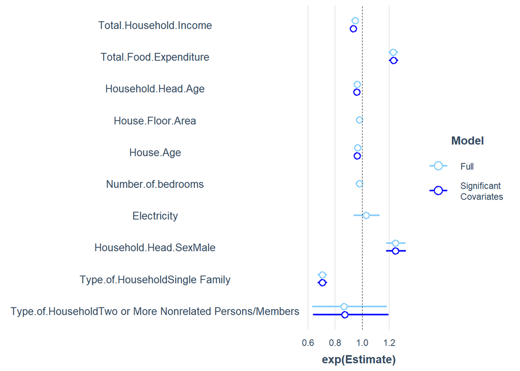

Summary of Coefficients for each fitted Poisson Model

Comparison of Fitted Poisson Models

| Model | AIC | BIC |
| --- | --- | --- |
| Full Model | 7011.64 | 7071.61 |
| Significant Factors Model | 7012.00 | 7055.62 |

From table 8, we find the AIC value of two fitted poisson models are very similar, however, the BIC value for the significant factors model is lower and so we accept the significant factors model as the better fit for the data.

The poisson regression model that will be fitted to the data is as follows:
$$log(\tilde{\lambda_i}) = \alpha + \beta_1 x_{1i} + \beta_2 x_{2i} + \beta_3 x_{3i} + \beta_4 x_{4i} + \widehat{\beta}_{\mbox{M}} \cdot \mathbb{I}_{\mbox{M}}(i)+\widehat{\beta}_{\mbox{S}} \cdot \mathbb{I}_{\mbox{S}}(i) + \epsilon_i, ~~~~ \epsilon \sim N(0, \sigma^2),$$
where

$$\mathbb{I}_{\mbox{M}}(i)=\left\{
\begin{array}{ll}
1 ~~~ \mbox{if the household head of} ~ i \mbox{th observation is Male},\\
0 ~~~ \mbox{Otherwise}.\\
\end{array}
\right.$$

- $\mathbb{I}_{\mbox{S}}(i)$ is an indicator function such that

$$\mathbb{I}_{\mbox{S}}(i)=\left\{
\begin{array}{ll}
1 ~~~ \mbox{if the type of household of} ~ i \mbox{th observation is Single Family},\\
0 ~~~ \mbox{Otherwise}.\\
\end{array}
\right.$$

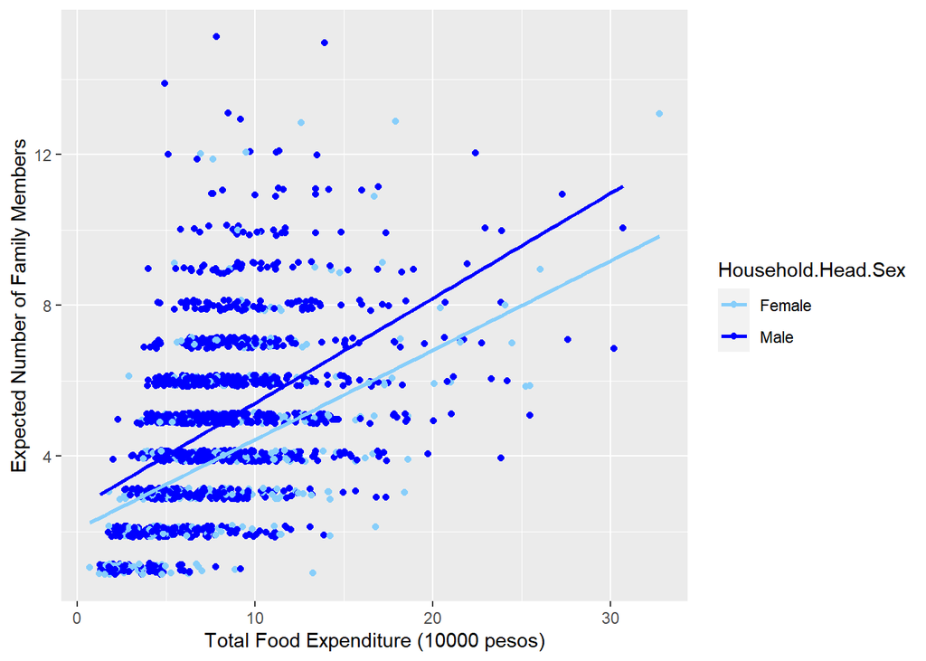

Predicted Numbers of Household Members and Food Expenditure

Figure 14 and Figure 15 show the expected, and observed, number of household members plotted against the covariate Total Food Expenditure, respectively. The fitted model lines of regression for the male and female groups can also be seen on these plots. For Figure 14, the two fitted lines can be seen to diverge as Food Expenditure increases, whereas in Figure 15, the two fitted lines can be seen converging as Food Expenditure, suggesting that the predicted model and hence predicted data could be improved upon.

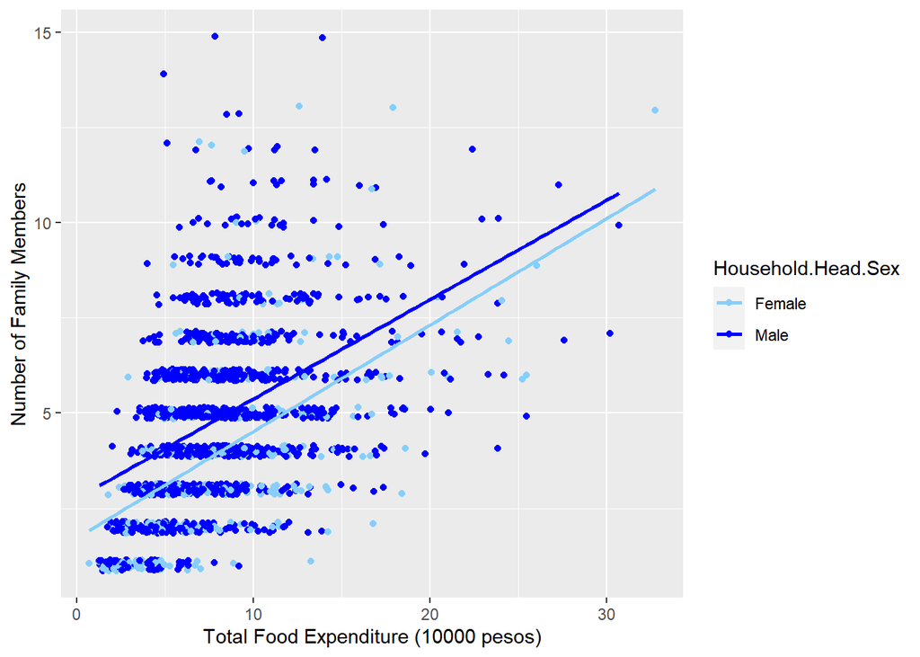

Observed Numbers of Household Members and Food Expenditure

Figure 16 shows the observed number of household members against the expected number of household members, there is a definite moderate positive correlation between these variables but it is not a perfect correlation. This suggests the model may be improved upon, which is an area for further analysis.

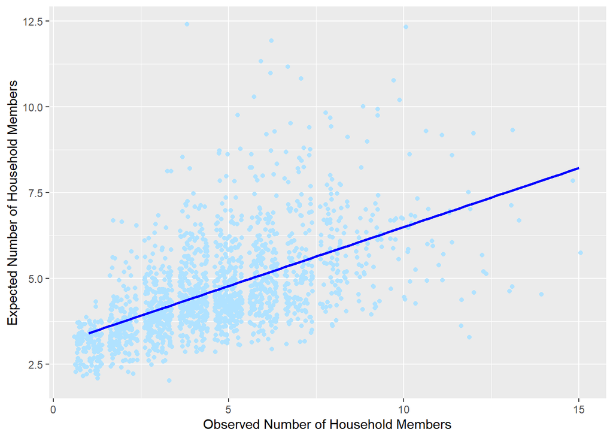

Predicted Numbers of Household Members against Observed Number of Household Members

# Conclusions

Combining the p-values and confidence intervals for each variable, we can conclude that Total Household Income, Total Food Expenditure, Head of Household Age and Sex, Age of the House, and if the Household is a Single or Extended Family, all have an effect on the number of members in a household.